# NOAA Storm Data Analysis

Chandan Mahodi

21 July 2018

## Synopsis:

This document is an analysis of the NOAA Storm Database. This database tracks characteristics of major storms and weather events in the United States, including when and where they occur, as well as estimates of any fatalities, injuries, and property damage.

Storms and other severe weather events can cause both public health and economic problems for communities and municipalities. Many severe events can result in fatalities, injuries, and property damage, and preventing such outcomes to the extent possible is a key concern.

This report can be helpful for preparing for severe weather events and simultaneously will help to prioritize resources for different types of events.

## Data Processing:

```r
setwd("C:/Users/user/Desktop/Data Analytics Stuff/Coursera/Reproducible research/Project2")
stormdata<-read.csv("repdata%2Fdata%2FStormData.csv.bz2",header=TRUE)
str(stormdata)
```

```
## 'data.frame':    902297 obs. of  37 variables:
##  $ STATE__   : num  1 1 1 1 1 1 1 1 1 1 ...
##  $ BGN_DATE  : Factor w/ 16335 levels "1/1/1966 0:00:00",..: 6523 6523 4242 11116 2224 2224 2260 383 3980 3980 ...
##  $ BGN_TIME  : Factor w/ 3608 levels "00:00:00 AM",..: 272 287 2705 1683 2584 3186 242 1683 3186 3186 ...
##  $ TIME_ZONE : Factor w/ 22 levels "ADT","AKS","AST",..: 7 7 7 7 7 7 7 7 7 7 ...
##  $ COUNTY    : num  97 3 57 89 43 77 9 123 125 57 ...
##  $ COUNTYNAME: Factor w/ 29601 levels "","5NM E OF MACKINAC BRIDGE TO PRESQUE ISLE LT MI",..: 13513 1873 4598 10592 4372 10094 1973 23873 24418 4598 ...
##  $ STATE     : Factor w/ 72 levels "AK","AL","AM",..: 2 2 2 2 2 2 2 2 2 2 ...
##  $ EVTYPE    : Factor w/ 985 levels "   HIGH SURF ADVISORY",..: 834 834 834 834 834 834 834 834 834 834 ...
##  $ BGN_RANGE : num  0 0 0 0 0 0 0 0 0 0 ...
##  $ BGN_AZI   : Factor w/ 35 levels "","  N"," NW",..: 1 1 1 1 1 1 1 1 1 1 ...
##  $ BGN_LOCATI: Factor w/ 54429 levels "","- 1 N Albion",..: 1 1 1 1 1 1 1 1 1 1 ...
##  $ END_DATE  : Factor w/ 6663 levels "","1/1/1993 0:00:00",..: 1 1 1 1 1 1 1 1 1 1 ...
##  $ END_TIME  : Factor w/ 3647 levels ""," 0900CST",..: 1 1 1 1 1 1 1 1 1 1 ...
##  $ COUNTY_END: num  0 0 0 0 0 0 0 0 0 0 ...
```

[output cut: 23 more lines]

## 1.Across the United States, which types of events are most harmful with respect to population health?

Selecting data pertaining Population Health

```r
dataFat<-tapply(stormdata$FATALITIES,stormdata$EVTYPE,sum)
dataInj<-tapply(stormdata$INJURIES,stormdata$EVTYPE,sum)
```

Sorting Fatalities and Injuries

```r
SortFat<-sort(dataFat,decreasing=TRUE)
SortInj<-sort(dataInj,decreasing=TRUE)
```

Most Harmful Types of Events

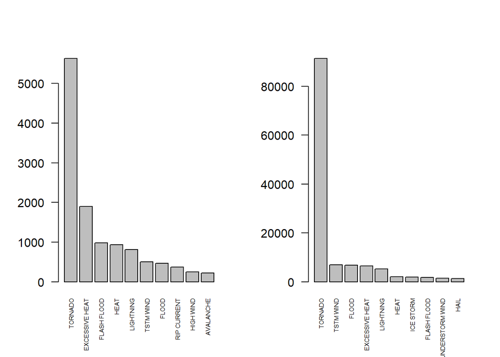

```r
library(graphics)
par(mfrow=c(1,2))
barplot(SortFat[1:10],las=2,cex.names = 0.5)
barplot(SortInj[1:10],las=2,cex.names = 0.5)
```

## Result:

The events which are most harmful with respect to population health are as follows:

```r
unique(names(SortInj[1:10]),names(SortFat[1:10]))
```

```
##  [1] "TORNADO"           "TSTM WIND"         "FLOOD"
##  [4] "EXCESSIVE HEAT"    "LIGHTNING"         "HEAT"
##  [7] "ICE STORM"         "FLASH FLOOD"       "THUNDERSTORM WIND"
## [10] "HAIL"
```

## 2.Across the United States, which types of events have the greatest economic consequences?

Selecting data pertaining Economical Damage

```r
library(dplyr)
newstormdata<-subset(stormdata,PROPDMGEXP=='M'|CROPDMGEXP=='M',select = c(EVTYPE,PROPDMG,CROPDMG))
newstormdata<-mutate(newstormdata,TTLDMG=PROPDMG+CROPDMG)
dataPD<-tapply(newstormdata$PROPDMG,newstormdata$EVTYPE,sum)
dataCD<-tapply(newstormdata$CROPDMG,newstormdata$EVTYPE,sum)
dataTD<-tapply(newstormdata$TTLDMG,newstormdata$EVTYPE,sum)
```

Sorting Damages

```r
sortedPD<-sort(dataPD,decreasing=TRUE)
sortedCD<-sort(dataCD,decreasing=TRUE)
sortedTD<-sort(dataTD,decreasing=TRUE)
```

Most Harmful Types of Events as per Economical Damage

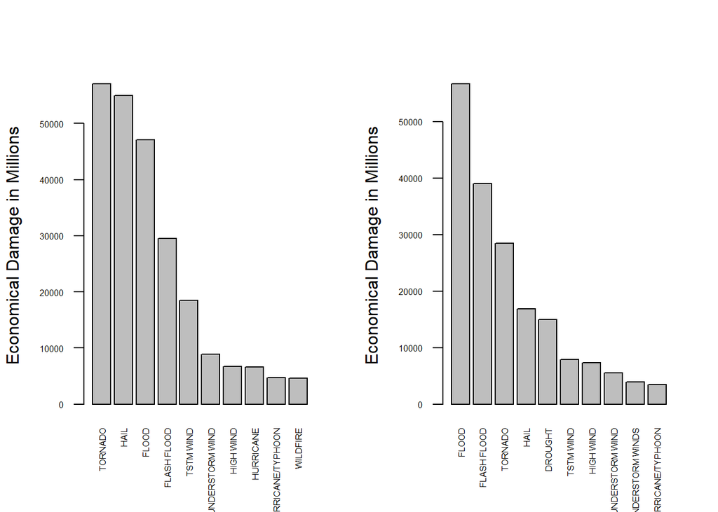

```r
library(graphics)
par(mfrow=c(1,2))
barplot(sortedPD[1:10],las=2,cex.names = 0.5,cex.axis = 0.5,ylab="Economical Damage in Millions")
barplot(sortedCD[1:10],las=2,cex.names = 0.5,cex.axis = 0.5,ylab="Economical Damage in Millions")
```

## Result:

The top 10 events which have greatst economic consequences are as follows:

```r
names(sortedTD[1:10])
```

```
##  [1] "FLOOD"             "TORNADO"           "HAIL"
##  [4] "FLASH FLOOD"       "TSTM WIND"         "DROUGHT"
##  [7] "THUNDERSTORM WIND" "HIGH WIND"         "HURRICANE"
## [10] "HURRICANE/TYPHOON"
```